# Summary of JAGS model

## Posterior Summary

|  | Lower95 | Median | Upper95 | Mean | SD | Mode | MCerr | MC%ofSD | SSeff | AC.10000 | psrf |
| --- | --- | --- | --- | --- | --- | --- | --- | --- | --- | --- | --- |
| **deviance** | 44510 | 44564 | 44614 | 44564 | 26.68 | 44565 | 0.3632 | 1.4 | 5393 | -0.008319 | 1 |
| **sire.vcov[1,1]** | 0.002299 | 3.081 | 8.623 | 3.626 | 2.637 | 2.261 | 0.03601 | 1.4 | 5364 | -0.001867 | 1 |
| **sire.vcov[2,1]** | -6.072 | 0.7987 | 8.756 | 1.091 | 3.775 | 0.4128 | 0.05049 | 1.3 | 5589 | -0.009243 | 1.001 |
| **sire.vcov[3,1]** | -0.2111 | 0.3933 | 1.375 | 0.4707 | 0.4335 | 0.2853 | 0.00597 | 1.4 | 5272 | -0.02889 | 1 |
| **sire.vcov[4,1]** | -0.9032 | -0.0456 | 0.7862 | -0.07104 | 0.4117 | -0.01549 | 0.005426 | 1.3 | 5759 | -0.01703 | 1.001 |
| **sire.vcov[1,2]** | -6.072 | 0.7987 | 8.756 | 1.091 | 3.775 | 0.4128 | 0.05049 | 1.3 | 5589 | -0.009243 | 1.001 |
| **sire.vcov[2,2]** | 0.7637 | 26.28 | 59.68 | 29.16 | 16.64 | 24.1 | 0.2294 | 1.4 | 5264 | 0.004428 | 1 |
| **sire.vcov[3,2]** | -1.454 | 0.192 | 2.45 | 0.2596 | 0.9667 | 0.03811 | 0.01353 | 1.4 | 5103 | -0.01394 | 1.002 |
| **sire.vcov[4,2]** | -1.558 | 0.3104 | 2.55 | 0.3685 | 1.018 | 0.2988 | 0.01366 | 1.3 | 5555 | 0.0127 | 1.001 |
| **sire.vcov[1,3]** | -0.2111 | 0.3933 | 1.375 | 0.4707 | 0.4335 | 0.2853 | 0.00597 | 1.4 | 5272 | -0.02889 | 1 |
| **sire.vcov[2,3]** | -1.454 | 0.192 | 2.45 | 0.2596 | 0.9667 | 0.03811 | 0.01353 | 1.4 | 5103 | -0.01394 | 1.002 |
| **sire.vcov[3,3]** | 0.0005693 | 0.2227 | 0.6438 | 0.2678 | 0.1996 | 0.1655 | 0.002882 | 1.4 | 4795 | -0.01197 | 1.002 |
| **sire.vcov[4,3]** | -0.1921 | 0.01317 | 0.2476 | 0.02291 | 0.1106 | 0.009144 | 0.001551 | 1.4 | 5086 | -0.009181 | 1.001 |
| **sire.vcov[1,4]** | -0.9032 | -0.0456 | 0.7862 | -0.07104 | 0.4117 | -0.01549 | 0.005426 | 1.3 | 5759 | -0.01703 | 1.001 |
| **sire.vcov[2,4]** | -1.558 | 0.3104 | 2.55 | 0.3685 | 1.018 | 0.2988 | 0.01366 | 1.3 | 5555 | 0.0127 | 1.001 |
| **sire.vcov[3,4]** | -0.1921 | 0.01317 | 0.2476 | 0.02291 | 0.1106 | 0.009144 | 0.001551 | 1.4 | 5086 | -0.009181 | 1.001 |
| **sire.vcov[4,4]** | 0.0007569 | 0.242 | 0.7042 | 0.2903 | 0.2201 | 0.1861 | 0.003093 | 1.4 | 5065 | 0.001927 | 0.9998 |
| **dam.vcov[1,1]** | 11.18 | 25.49 | 49.35 | 27.47 | 10.7 | 22.95 | 0.1467 | 1.4 | 5322 | -0.005967 | 1 |
| **dam.vcov[2,1]** | -5.503 | 24.02 | 66.8 | 26.26 | 18.84 | 21.75 | 0.2522 | 1.3 | 5580 | -0.0473 | 1 |
| **dam.vcov[3,1]** | -0.5926 | 1.498 | 3.858 | 1.612 | 1.158 | 1.41 | 0.01565 | 1.4 | 5474 | 0.01303 | 1.001 |
| **dam.vcov[4,1]** | -1.319 | 0.4745 | 2.678 | 0.5495 | 1.015 | 0.3931 | 0.01424 | 1.4 | 5079 | -0.01004 | 0.9994 |
| **dam.vcov[1,2]** | -5.503 | 24.02 | 66.8 | 26.26 | 18.84 | 21.75 | 0.2522 | 1.3 | 5580 | -0.0473 | 1 |
| **dam.vcov[2,2]** | 79.79 | 177.1 | 330.8 | 190.4 | 70.01 | 164.6 | 0.9069 | 1.3 | 5961 | -0.009738 | 1 |
| **dam.vcov[3,2]** | -1.137 | 3.95 | 10.37 | 4.291 | 2.98 | 3.597 | 0.03817 | 1.3 | 6094 | -0.03876 | 1.001 |
| **dam.vcov[4,2]** | -7.392 | -2.13 | 2.181 | -2.368 | 2.424 | -1.879 | 0.03319 | 1.4 | 5335 | -0.006233 | 1.002 |
| **dam.vcov[1,3]** | -0.5926 | 1.498 | 3.858 | 1.612 | 1.158 | 1.41 | 0.01565 | 1.4 | 5474 | 0.01303 | 1.001 |
| **dam.vcov[2,3]** | -1.137 | 3.95 | 10.37 | 4.291 | 2.98 | 3.597 | 0.03817 | 1.3 | 6094 | -0.03876 | 1.001 |
| **dam.vcov[3,3]** | 0.09376 | 0.5073 | 1.182 | 0.5703 | 0.31 | 0.4406 | 0.004244 | 1.4 | 5336 | -0.0146 | 1.001 |
| **dam.vcov[4,3]** | -0.522 | -0.1654 | 0.09044 | -0.1813 | 0.1574 | -0.1469 | 0.002068 | 1.3 | 5792 | -0.005943 | 1 |
| **dam.vcov[1,4]** | -1.319 | 0.4745 | 2.678 | 0.5495 | 1.015 | 0.3931 | 0.01424 | 1.4 | 5079 | -0.01004 | 0.9994 |

[output cut: 97 more lines]

## V<sub>A</sub>

Latent scale

| metric | lower.hdi | median | mode | upper.hdi | pr.lt.hdi | pr.gt.hdi | 5pc.exceeds | pct.gt.0 |
| --- | --- | --- | --- | --- | --- | --- | --- | --- |
| Var(Trunk) | 0.009196 | 12.32 | 9.079 | 34.49 | 0 | 0.0498 | 34.45 | 1 |
| Var(Tail) | 3.055 | 105.1 | 97.1 | 238.7 | 0.0014 | 0.0484 | 236.4 | 1 |
| Var(Hatch) | 0.002277 | 0.8906 | 0.6687 | 2.575 | 0.0004 | 0.0494 | 2.571 | 1 |
| Var(Settle\|Hatch) | 0.003028 | 0.968 | 0.7343 | 2.817 | 0.0006 | 0.0492 | 2.814 | 1 |
| Cov(Trunk, Tail) | -24.29 | 3.195 | 1.613 | 35.02 | 0.0192 | 0.0306 | 29.75 | 0.6072 |
| Cov(Trunk, Hatch) | -0.8444 | 1.573 | 1.137 | 5.499 | 0.014 | 0.0358 | 5.098 | 0.9102 |
| Cov(Trunk, Settle\|Hatch) | -3.613 | -0.1824 | -0.04448 | 3.145 | 0.0298 | 0.02 | 2.23 | 0.4304 |
| Cov(Tail, Hatch) | -5.816 | 0.7682 | 0.0737 | 9.802 | 0.0304 | 0.0194 | 7.433 | 0.609 |
| Cov(Tail, Settle\|Hatch) | -6.232 | 1.242 | 1.25 | 10.2 | 0.0252 | 0.0246 | 8.278 | 0.6568 |
| Cov(Hatch, Settle\|Hatch) | -0.7684 | 0.05267 | 0.0465 | 0.9904 | 0.0208 | 0.029 | 0.8138 | 0.5716 |

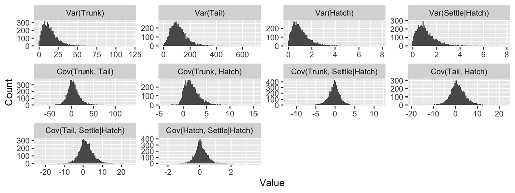

## V<sub>M</sub>

Latent scale

| metric | lower.hdi | median | mode | upper.hdi | pr.lt.hdi | pr.gt.hdi | 5pc.exceeds | pct.gt.0 |
| --- | --- | --- | --- | --- | --- | --- | --- | --- |
| Var(Trunk) | 5.639 | 22.04 | 20.4 | 45.96 | 0.0106 | 0.0392 | 43.9 | 0.9988 |
| Var(Tail) | 46.53 | 148.6 | 128.4 | 309.8 | 0.01 | 0.0398 | 296 | 0.9994 |
| Var(Hatch) | -0.3679 | 0.2729 | 0.217 | 1.041 | 0.0194 | 0.0304 | 0.9101 | 0.843 |
| Var(Settle\|Hatch) | -0.5421 | 0.1023 | 0.1175 | 0.7546 | 0.0222 | 0.0276 | 0.6229 | 0.6686 |
| Cov(Trunk, Tail) | -10.27 | 23.07 | 19.68 | 64.68 | 0.016 | 0.0338 | 59.68 | 0.9436 |
| Cov(Trunk, Hatch) | -1.046 | 1.053 | 0.9037 | 3.678 | 0.0206 | 0.0292 | 3.184 | 0.8534 |
| Cov(Trunk, Settle\|Hatch) | -1.527 | 0.5557 | 0.4434 | 2.832 | 0.0204 | 0.0294 | 2.495 | 0.7224 |
| Cov(Tail, Hatch) | -1.99 | 3.765 | 3.341 | 10.19 | 0.0146 | 0.0352 | 9.412 | 0.9312 |
| Cov(Tail, Settle\|Hatch) | -8.396 | -2.515 | -2.041 | 1.971 | 0.027 | 0.0228 | 1.056 | 0.1216 |
| Cov(Hatch, Settle\|Hatch) | -0.5736 | -0.1905 | -0.1787 | 0.1718 | 0.0344 | 0.0154 | 0.07845 | 0.1202 |

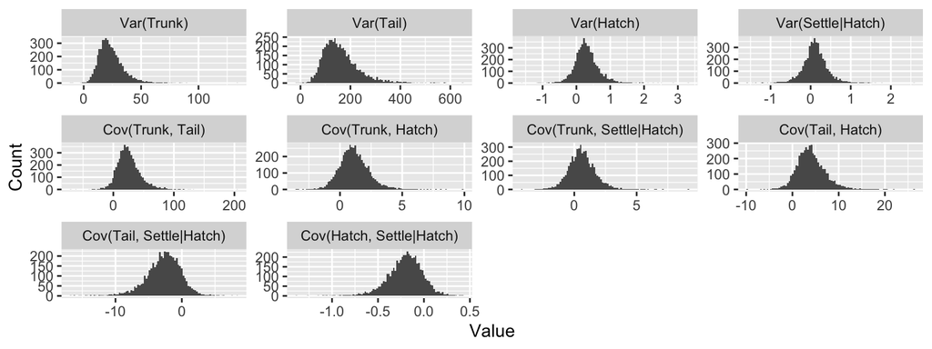

## V<sub>D</sub>

Latent scale

| metric | lower.hdi | median | mode | upper.hdi | pr.lt.hdi | pr.gt.hdi | 5pc.exceeds | pct.gt.0 |
| --- | --- | --- | --- | --- | --- | --- | --- | --- |
| Var(Trunk) | 0.002497 | 9.003 | 4.915 | 26.65 | 0 | 0.0498 | 26.65 | 1 |
| Var(Tail) | 0.5466 | 72 | 59.78 | 165.9 | 0.0004 | 0.0494 | 165.8 | 1 |
| Var(Hatch) | 0.1253 | 0.9951 | 0.8108 | 2.322 | 0.0112 | 0.0386 | 2.225 | 1 |
| Var(Settle\|Hatch) | 0.5065 | 1.362 | 1.218 | 2.471 | 0.0048 | 0.045 | 2.443 | 1 |
| Cov(Trunk, Tail) | -12.39 | 5.798 | 2.881 | 32.99 | 0.0144 | 0.0354 | 29.76 | 0.7496 |
| Cov(Trunk, Hatch) | -2.924 | -0.4555 | -0.4172 | 2.314 | 0.029 | 0.0208 | 1.598 | 0.3234 |
| Cov(Trunk, Settle\|Hatch) | -3.381 | -0.443 | -0.297 | 1.852 | 0.0166 | 0.0332 | 1.576 | 0.345 |
| Cov(Tail, Hatch) | -4.799 | 1.298 | 1.133 | 8.081 | 0.02 | 0.0298 | 6.967 | 0.6886 |
| Cov(Tail, Settle\|Hatch) | -7.537 | -1.036 | -0.8596 | 4.443 | 0.0218 | 0.028 | 3.597 | 0.3478 |
| Cov(Hatch, Settle\|Hatch) | -0.4575 | 0.2248 | 0.224 | 0.9226 | 0.022 | 0.0278 | 0.7982 | 0.7668 |

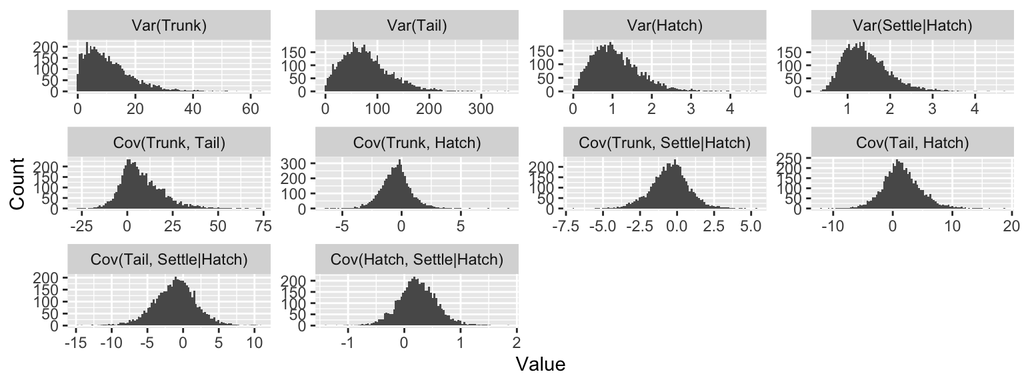

## V<sub>R</sub>

Latent scale

| metric | lower.hdi | median | mode | upper.hdi | pr.lt.hdi | pr.gt.hdi | 5pc.exceeds | pct.gt.0 |
| --- | --- | --- | --- | --- | --- | --- | --- | --- |
| Var(Trunk) | 81.83 | 88.98 | 88.6 | 96.98 | 0.0244 | 0.0254 | 95.65 | 1 |
| Var(Tail) | 302.8 | 329.4 | 328.7 | 358.6 | 0.0248 | 0.025 | 354.2 | 1 |
| Var(Hatch) | 0 | 0 | 0 | 0 | 0 | 0 | 0 | 0 |
| Var(Settle\|Hatch) | 0 | 0 | 0 | 0 | 0 | 0 | 0 | 0 |
| Cov(Trunk, Tail) | 40.63 | 51.05 | 49.9 | 61.78 | 0.0226 | 0.0272 | 60.35 | 1 |
| Cov(Trunk, Hatch) | 0 | 0 | 0 | 0 | 0 | 0 | 0 | 0 |
| Cov(Trunk, Settle\|Hatch) | 0 | 0 | 0 | 0 | 0 | 0 | 0 | 0 |
| Cov(Tail, Hatch) | 0 | 0 | 0 | 0 | 0 | 0 | 0 | 0 |
| Cov(Tail, Settle\|Hatch) | 0 | 0 | 0 | 0 | 0 | 0 | 0 | 0 |
| Cov(Hatch, Settle\|Hatch) | 0 | 0 | 0 | 0 | 0 | 0 | 0 | 0 |

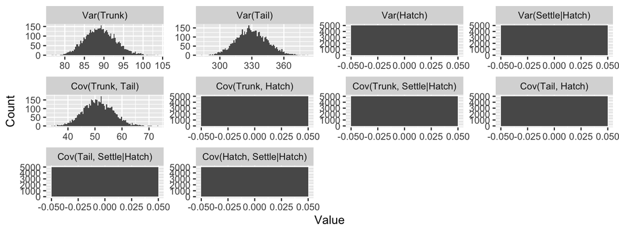

## V<sub>P</sub>

Latent scale

| metric | lower.hdi | median | mode | upper.hdi | pr.lt.hdi | pr.gt.hdi | 5pc.exceeds | pct.gt.0 |
| --- | --- | --- | --- | --- | --- | --- | --- | --- |
| Var(Trunk) | 103.1 | 121.2 | 118.3 | 145.4 | 0.0084 | 0.0414 | 144.1 | 1 |
| Var(Tail) | 449.1 | 556.5 | 539.8 | 719.3 | 0.0082 | 0.0416 | 709.5 | 1 |
| Var(Hatch) | 0.5207 | 1.046 | 0.9588 | 1.858 | 0.0092 | 0.0406 | 1.783 | 1 |
| Var(Settle\|Hatch) | 0.5098 | 0.99 | 0.9086 | 1.705 | 0.0062 | 0.0436 | 1.658 | 1 |
| Cov(Trunk, Tail) | 45.14 | 78.46 | 74.62 | 121.6 | 0.0182 | 0.0316 | 115.2 | 0.9996 |
| Cov(Trunk, Hatch) | -0.2892 | 1.825 | 1.643 | 4.513 | 0.0188 | 0.031 | 4.131 | 0.9648 |
| Cov(Trunk, Settle\|Hatch) | -1.913 | 0.3099 | 0.3233 | 2.459 | 0.0166 | 0.0332 | 2.221 | 0.6266 |
| Cov(Tail, Hatch) | -0.8659 | 4.688 | 4.587 | 11.29 | 0.0176 | 0.0322 | 10.38 | 0.9656 |
| Cov(Tail, Settle\|Hatch) | -7.556 | -2.111 | -1.829 | 3 | 0.0344 | 0.0154 | 1.671 | 0.1714 |
| Cov(Hatch, Settle\|Hatch) | -0.5026 | -0.09213 | -0.08823 | 0.2923 | 0.0278 | 0.022 | 0.2046 | 0.292 |

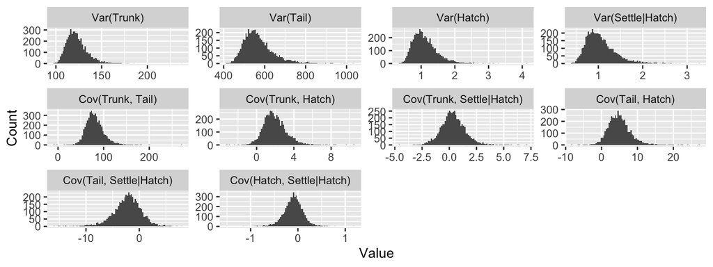

## V<sub>M</sub> / V<sub>A</sub>

Latent scale

| metric | lower.hdi | median | mode | upper.hdi | pr.lt.hdi | pr.gt.hdi | 5pc.exceeds | pct.gt.1 |
| --- | --- | --- | --- | --- | --- | --- | --- | --- |
| Var(Trunk) | -0.1129 | 1.919 | 1.164 | 13.12 | 0 | 0.0498 | 13.11 | 0.751 |
| Var(Tail) | -0.02808 | 1.471 | 0.9945 | 6.112 | 0 | 0.0498 | 6.076 | 0.6942 |
| Var(Hatch) | -0.2325 | 0.3268 | 0.1337 | 3.255 | 0 | 0.0498 | 3.253 | 0.2094 |
| Var(Settle\|Hatch) | -0.2442 | 0.1201 | 0.00502 | 2.248 | 0 | 0.0498 | 2.239 | 0.117 |
| Cov(Trunk, Tail) | -37.18 | 0.5455 | 0.2669 | 43.1 | 0.0266 | 0.0232 | 17.47 | 0.4324 |
| Cov(Trunk, Hatch) | -10.05 | 0.4962 | 0.3115 | 12.24 | 0.0246 | 0.0252 | 6.631 | 0.317 |
| Cov(Trunk, Settle\|Hatch) | -12.73 | -0.3136 | -0.3801 | 12.66 | 0.0246 | 0.0252 | 6.034 | 0.1742 |
| Cov(Tail, Hatch) | -22.77 | 0.2755 | 0.1184 | 25.31 | 0.027 | 0.0228 | 11.27 | 0.3492 |
| Cov(Tail, Settle\|Hatch) | -11.71 | -0.5128 | -0.4677 | 13.48 | 0.0282 | 0.0216 | 6.434 | 0.1662 |
| Cov(Hatch, Settle\|Hatch) | -12.34 | -0.3555 | -0.2706 | 7.692 | 0.0192 | 0.0306 | 4.868 | 0.1676 |

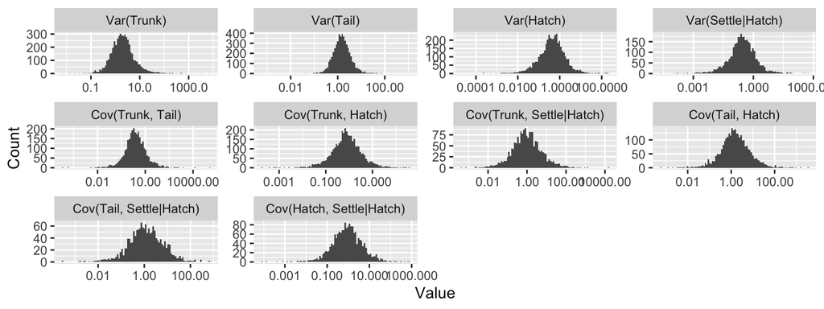

## V<sub>D</sub> / V<sub>A</sub>

Latent scale

| metric | lower.hdi | median | mode | upper.hdi | pr.lt.hdi | pr.gt.hdi | 5pc.exceeds | pct.gt.1 |
| --- | --- | --- | --- | --- | --- | --- | --- | --- |
| Var(Trunk) | 0.0002512 | 0.6851 | 0.3436 | 8.21 | 0 | 0.0498 | 8.206 | 0.3938 |
| Var(Tail) | 0.002913 | 0.6455 | 0.4433 | 3.832 | 0.0002 | 0.0496 | 3.829 | 0.3236 |
| Var(Hatch) | 0.0009074 | 1.073 | 0.6136 | 10.13 | 0 | 0.0498 | 10.1 | 0.5256 |
| Var(Settle\|Hatch) | 0.07075 | 1.372 | 0.8663 | 11.87 | 0 | 0.0498 | 11.85 | 0.646 |
| Cov(Trunk, Tail) | -14.58 | 0.02765 | -0.01026 | 14.24 | 0.0238 | 0.026 | 7.019 | 0.238 |
| Cov(Trunk, Hatch) | -10.43 | -0.234 | -0.2167 | 7.097 | 0.021 | 0.0288 | 3.794 | 0.1138 |
| Cov(Trunk, Settle\|Hatch) | -15.05 | -0.02887 | -0.1138 | 17.18 | 0.0242 | 0.0256 | 8.39 | 0.2282 |
| Cov(Tail, Hatch) | -16.36 | -0.01481 | 0.02435 | 13.74 | 0.0214 | 0.0284 | 7.735 | 0.2322 |
| Cov(Tail, Settle\|Hatch) | -11.21 | -0.2504 | -0.2469 | 12.22 | 0.0272 | 0.0226 | 5.504 | 0.1702 |
| Cov(Hatch, Settle\|Hatch) | -17.27 | 0.0264 | 0.04858 | 16.83 | 0.0256 | 0.0242 | 9.003 | 0.2716 |

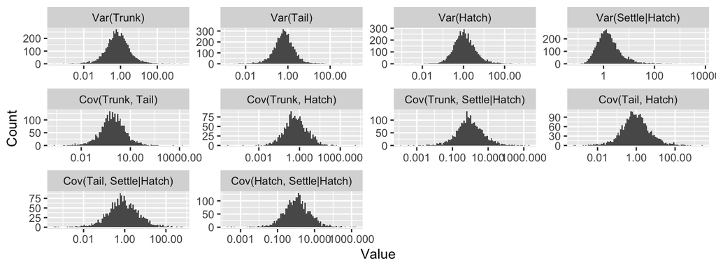

## Variance partitioning

Latent scale  
$(VA / VP) \times 100$

|  | Trunk | Tail |
| --- | --- | --- |
| **lower.hdi** | 0.006469 | 1.434 |
| **median** | 10.06 | 18.69 |
| **mode** | 7.98 | 16.18 |
| **upper.hdi** | 27.23 | 41.8 |
| **pr.lt.hdi** | 0 | 0.0056 |
| **pr.gt.hdi** | 0.0498 | 0.0442 |
| **5pc.exceeds** | 27.2 | 40.91 |

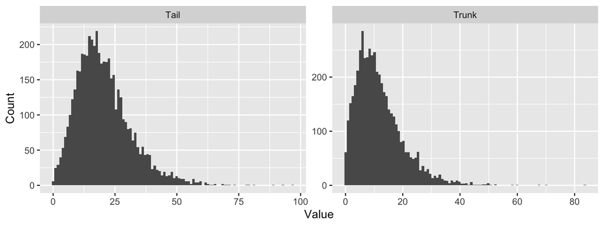

$(VM / VP) \times 100$

|  | Trunk | Tail |
| --- | --- | --- |
| **lower.hdi** | 5.692 | 10.88 |
| **median** | 18.38 | 27 |
| **mode** | 17.63 | 26.52 |
| **upper.hdi** | 32.54 | 45.03 |
| **pr.lt.hdi** | 0.0146 | 0.0168 |
| **pr.gt.hdi** | 0.0352 | 0.033 |
| **5pc.exceeds** | 31.11 | 42.51 |

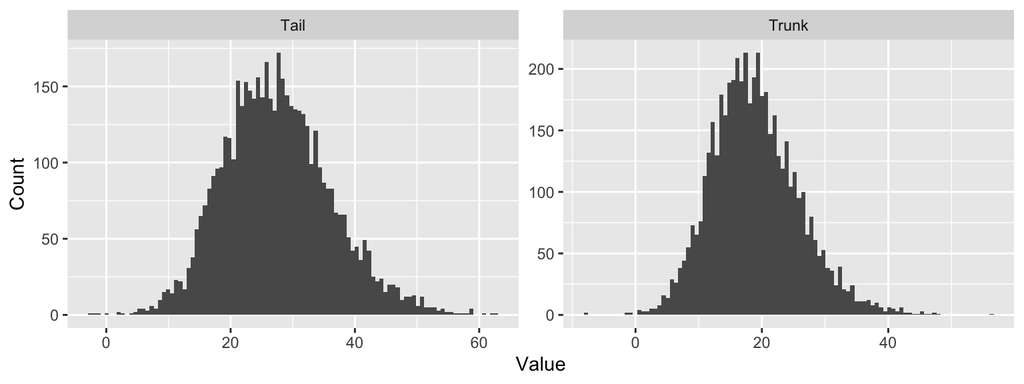

$(VD / VP) \times 100$

|  | Trunk | Tail |
| --- | --- | --- |
| **lower.hdi** | 0.002292 | 0.1201 |
| **median** | 7.363 | 12.73 |
| **mode** | 3.922 | 11.59 |
| **upper.hdi** | 21.85 | 30.28 |
| **pr.lt.hdi** | 0 | 0.0006 |
| **pr.gt.hdi** | 0.0498 | 0.0492 |
| **5pc.exceeds** | 21.84 | 30.21 |

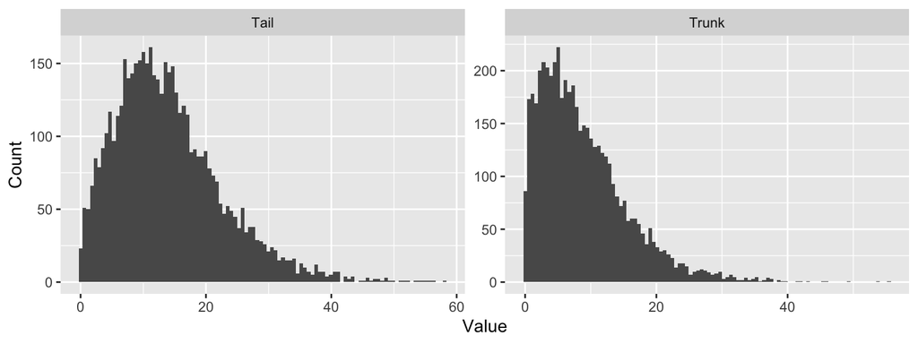

## Summarize QGmvparams posteriors

### Block means on expected data scale

Hatching actually measured in blocks 5, 7, 8, 9, 10, 11, 12, 13, 14, 16  
Settling actually measured in blocks 3, 4, 5, 7, 8, 9, 10, 11, 12, 14  
But **Block** has been re-coded for running model in runjags().

| Block | Stage | lower.hdi | median | mode | upper.hdi | pr.lt.hdi | pr.gt.hdi | 5pc.exceeds |
| --- | --- | --- | --- | --- | --- | --- | --- | --- |
| 3 | Hatch | NA | NA | NA | NA | NA | NA | NA |
| 4 | Hatch | NA | NA | NA | NA | NA | NA | NA |
| 5 | Hatch | 0.5 | 0.77 | 0.82 | 0.96 | 0.041 | 0.0086 | 0.93 |
| 7 | Hatch | 0.54 | 0.79 | 0.84 | 0.96 | 0.046 | 0.0042 | 0.93 |
| 8 | Hatch | 0.53 | 0.78 | 0.82 | 0.96 | 0.044 | 0.006 | 0.93 |
| 9 | Hatch | 0.67 | 0.87 | 0.91 | 0.98 | 0.05 | 0 | 0.96 |
| 10 | Hatch | 0.45 | 0.71 | 0.74 | 0.91 | 0.016 | 0.034 | 0.9 |
| 11 | Hatch | 0.47 | 0.72 | 0.77 | 0.92 | 0.03 | 0.02 | 0.9 |
| 12 | Hatch | 0.69 | 0.89 | 0.92 | 0.98 | 0.049 | 0.0006 | 0.96 |
| 13 | Hatch | 0.56 | 0.8 | 0.85 | 0.97 | 0.048 | 0.002 | 0.93 |
| 14 | Hatch | 0.63 | 0.85 | 0.89 | 0.97 | 0.049 | 0.0012 | 0.95 |
| 16 | Hatch | 0.76 | 0.92 | 0.94 | 0.98 | 0.049 | 0.0006 | 0.97 |
| 3 | Settle\|Hatch | 0.5 | 0.82 | 0.89 | 0.97 | 0.049 | 0.0004 | 0.95 |
| 4 | Settle\|Hatch | 0.56 | 0.85 | 0.91 | 0.97 | 0.049 | 0.0006 | 0.96 |
| 5 | Settle\|Hatch | 0.41 | 0.74 | 0.82 | 0.96 | 0.045 | 0.005 | 0.93 |
| 7 | Settle\|Hatch | 0.62 | 0.86 | 0.91 | 0.97 | 0.05 | 0.0002 | 0.96 |
| 8 | Settle\|Hatch | 0.45 | 0.76 | 0.83 | 0.96 | 0.046 | 0.0036 | 0.93 |
| 9 | Settle\|Hatch | 0.33 | 0.65 | 0.72 | 0.92 | 0.033 | 0.017 | 0.88 |
| 10 | Settle\|Hatch | 0.34 | 0.66 | 0.69 | 0.93 | 0.04 | 0.01 | 0.9 |
| 11 | Settle\|Hatch | 0.33 | 0.64 | 0.69 | 0.91 | 0.029 | 0.02 | 0.88 |
| 12 | Settle\|Hatch | 0.34 | 0.65 | 0.7 | 0.92 | 0.037 | 0.013 | 0.88 |
| 13 | Settle\|Hatch | NA | NA | NA | NA | NA | NA | NA |
| 14 | Settle\|Hatch | 0.55 | 0.82 | 0.88 | 0.97 | 0.048 | 0.0018 | 0.95 |
| 16 | Settle\|Hatch | NA | NA | NA | NA | NA | NA | NA |

Summary across blocks

| Stage | min | max | mean_median | mean_mode |
| --- | --- | --- | --- | --- |
| Hatch | 0.71 | 0.92 | 0.81 | 0.85 |
| Settle\|Hatch | 0.64 | 0.86 | 0.74 | 0.8 |

### Block means on latent scale

| Block | Hatch | Settle\|Hatch |
| --- | --- | --- |
| 3 | NA | 1.8 |
| 4 | NA | 2 |
| 5 | 1.5 | 1.3 |
| 7 | 1.6 | 2.2 |
| 8 | 1.5 | 1.4 |
| 9 | 2.3 | 0.76 |
| 10 | 1.1 | 0.83 |
| 11 | 1.2 | 0.77 |
| 12 | 2.4 | 0.78 |
| 13 | 1.7 | NA |
| 14 | 2.1 | 1.8 |
| 16 | 2.8 | NA |

### VA for settling and hatching on data scale across blocks

| Block | Stage | lower.hdi | median | mode | upper.hdi | pr.lt.hdi | pr.gt.hdi | 5pc.exceeds | pct.gt.0 |
| --- | --- | --- | --- | --- | --- | --- | --- | --- | --- |
| 1 | Var(Hatch) | 0.0023 | 0.89 | 0.67 | 2.6 | 0.0004 | 0.049 | 2.6 | 1 |
| 2 | Var(Hatch) | 0.0023 | 0.89 | 0.67 | 2.6 | 0.0004 | 0.049 | 2.6 | 1 |
| 3 | Var(Hatch) | 0.0023 | 0.89 | 0.67 | 2.6 | 0.0004 | 0.049 | 2.6 | 1 |
| 4 | Var(Hatch) | 0.0023 | 0.89 | 0.67 | 2.6 | 0.0004 | 0.049 | 2.6 | 1 |
| 5 | Var(Hatch) | 0.000016 | 0.017 | 0.0086 | 0.069 | 0.0002 | 0.05 | 0.069 | 1 |
| 7 | Var(Hatch) | 0.000027 | 0.015 | 0.0078 | 0.067 | 0.0002 | 0.05 | 0.067 | 1 |
| 8 | Var(Hatch) | 0.000016 | 0.016 | 0.0087 | 0.068 | 0 | 0.05 | 0.068 | 1 |
| 9 | Var(Hatch) | 0.000004 | 0.0074 | 0.0037 | 0.048 | 0 | 0.05 | 0.048 | 1 |
| 10 | Var(Hatch) | 0.000028 | 0.022 | 0.011 | 0.078 | 0 | 0.05 | 0.078 | 1 |
| 11 | Var(Hatch) | 0.000029 | 0.022 | 0.011 | 0.075 | 0 | 0.05 | 0.075 | 1 |
| 12 | Var(Hatch) | 0.0000038 | 0.0065 | 0.0032 | 0.041 | 0 | 0.05 | 0.041 | 1 |
| 13 | Var(Hatch) | 0.000013 | 0.015 | 0.0075 | 0.065 | 0 | 0.05 | 0.065 | 1 |
| 14 | Var(Hatch) | 0.0000087 | 0.0098 | 0.0049 | 0.053 | 0 | 0.05 | 0.053 | 1 |
| 15 | Var(Hatch) | 0.0023 | 0.89 | 0.67 | 2.6 | 0.0004 | 0.049 | 2.6 | 1 |
| 16 | Var(Hatch) | 0.0000025 | 0.0038 | 0.0019 | 0.03 | 0 | 0.05 | 0.03 | 1 |
| 1 | Var(Settle\|Hatch) | 0.003 | 0.97 | 0.73 | 2.8 | 0.0006 | 0.049 | 2.8 | 1 |
| 2 | Var(Settle\|Hatch) | 0.003 | 0.97 | 0.73 | 2.8 | 0.0006 | 0.049 | 2.8 | 1 |
| 3 | Var(Settle\|Hatch) | 0.00000084 | 0.014 | 0.007 | 0.067 | 0 | 0.05 | 0.067 | 1 |
| 4 | Var(Settle\|Hatch) | 0.0000014 | 0.01 | 0.0052 | 0.063 | 0 | 0.05 | 0.063 | 1 |
| 5 | Var(Settle\|Hatch) | 0.0000053 | 0.022 | 0.011 | 0.08 | 0 | 0.05 | 0.08 | 1 |
| 7 | Var(Settle\|Hatch) | 0.00000047 | 0.0092 | 0.0046 | 0.056 | 0 | 0.05 | 0.056 | 1 |
| 8 | Var(Settle\|Hatch) | 0.00000077 | 0.02 | 0.0099 | 0.078 | 0 | 0.05 | 0.078 | 1 |
| 9 | Var(Settle\|Hatch) | 0.0000031 | 0.028 | 0.015 | 0.089 | 0 | 0.05 | 0.089 | 1 |
| 10 | Var(Settle\|Hatch) | 0.0000057 | 0.027 | 0.014 | 0.088 | 0 | 0.05 | 0.087 | 1 |
| 11 | Var(Settle\|Hatch) | 0.0000029 | 0.029 | 0.018 | 0.09 | 0 | 0.05 | 0.09 | 1 |
| 12 | Var(Settle\|Hatch) | 0.000002 | 0.028 | 0.014 | 0.088 | 0 | 0.05 | 0.088 | 1 |
| 13 | Var(Settle\|Hatch) | 0.003 | 0.97 | 0.73 | 2.8 | 0.0006 | 0.049 | 2.8 | 1 |
| 14 | Var(Settle\|Hatch) | 0.000001 | 0.014 | 0.007 | 0.066 | 0 | 0.05 | 0.066 | 1 |
| 15 | Var(Settle\|Hatch) | 0.003 | 0.97 | 0.73 | 2.8 | 0.0006 | 0.049 | 2.8 | 1 |
| 16 | Var(Settle\|Hatch) | 0.003 | 0.97 | 0.73 | 2.8 | 0.0006 | 0.049 | 2.8 | 1 |

[output cut: 75 more lines]

### VP for settling and hatching on data scale across blocks

| Block | Stage | lower.hdi | median | mode | upper.hdi | pr.lt.hdi | pr.gt.hdi | 5pc.exceeds | pct.gt.0 |
| --- | --- | --- | --- | --- | --- | --- | --- | --- | --- |
| 1 | Var(Hatch) | 0.52 | 1 | 0.96 | 1.9 | 0.0092 | 0.041 | 1.8 | 1 |
| 2 | Var(Hatch) | 0.52 | 1 | 0.96 | 1.9 | 0.0092 | 0.041 | 1.8 | 1 |
| 3 | Var(Hatch) | 0.52 | 1 | 0.96 | 1.9 | 0.0092 | 0.041 | 1.8 | 1 |
| 4 | Var(Hatch) | 0.52 | 1 | 0.96 | 1.9 | 0.0092 | 0.041 | 1.8 | 1 |
| 5 | Var(Hatch) | 0.065 | 0.18 | 0.21 | 0.25 | 0.05 | 0 | 0.25 | 1 |
| 7 | Var(Hatch) | 0.063 | 0.17 | 0.21 | 0.25 | 0.05 | 0 | 0.25 | 1 |
| 8 | Var(Hatch) | 0.069 | 0.17 | 0.21 | 0.25 | 0.05 | 0 | 0.25 | 1 |
| 9 | Var(Hatch) | 0.026 | 0.11 | 0.082 | 0.22 | 0.0022 | 0.048 | 0.22 | 1 |
| 10 | Var(Hatch) | 0.091 | 0.21 | 0.23 | 0.25 | 0.05 | 0 | 0.25 | 1 |
| 11 | Var(Hatch) | 0.092 | 0.2 | 0.23 | 0.25 | 0.049 | 0.0004 | 0.25 | 1 |
| 12 | Var(Hatch) | 0.026 | 0.1 | 0.071 | 0.22 | 0.003 | 0.047 | 0.21 | 1 |
| 13 | Var(Hatch) | 0.063 | 0.16 | 0.21 | 0.25 | 0.05 | 0.0002 | 0.25 | 1 |
| 14 | Var(Hatch) | 0.035 | 0.13 | 0.11 | 0.24 | 0.015 | 0.035 | 0.23 | 1 |
| 15 | Var(Hatch) | 0.52 | 1 | 0.96 | 1.9 | 0.0092 | 0.041 | 1.8 | 1 |
| 16 | Var(Hatch) | 0.024 | 0.075 | 0.053 | 0.18 | 0.0012 | 0.049 | 0.18 | 1 |
| 1 | Var(Settle\|Hatch) | 0.51 | 0.99 | 0.91 | 1.7 | 0.0062 | 0.044 | 1.7 | 1 |
| 2 | Var(Settle\|Hatch) | 0.51 | 0.99 | 0.91 | 1.7 | 0.0062 | 0.044 | 1.7 | 1 |
| 3 | Var(Settle\|Hatch) | 0.044 | 0.15 | 0.2 | 0.25 | 0.05 | 0.0002 | 0.25 | 1 |
| 4 | Var(Settle\|Hatch) | 0.038 | 0.13 | 0.082 | 0.25 | 0.049 | 0.0006 | 0.24 | 1 |
| 5 | Var(Settle\|Hatch) | 0.066 | 0.19 | 0.22 | 0.25 | 0.05 | 0 | 0.25 | 1 |
| 7 | Var(Settle\|Hatch) | 0.028 | 0.12 | 0.084 | 0.24 | 0.0062 | 0.044 | 0.23 | 1 |
| 8 | Var(Settle\|Hatch) | 0.063 | 0.18 | 0.22 | 0.25 | 0.05 | 0 | 0.25 | 1 |
| 9 | Var(Settle\|Hatch) | 0.1 | 0.22 | 0.24 | 0.25 | 0.05 | 0 | 0.25 | 1 |
| 10 | Var(Settle\|Hatch) | 0.092 | 0.22 | 0.23 | 0.25 | 0.05 | 0 | 0.25 | 1 |
| 11 | Var(Settle\|Hatch) | 0.1 | 0.22 | 0.24 | 0.25 | 0.05 | 0.0002 | 0.25 | 1 |
| 12 | Var(Settle\|Hatch) | 0.1 | 0.22 | 0.24 | 0.25 | 0.05 | 0.0002 | 0.25 | 1 |
| 13 | Var(Settle\|Hatch) | 0.51 | 0.99 | 0.91 | 1.7 | 0.0062 | 0.044 | 1.7 | 1 |
| 14 | Var(Settle\|Hatch) | 0.046 | 0.15 | 0.2 | 0.25 | 0.05 | 0.0002 | 0.25 | 1 |
| 15 | Var(Settle\|Hatch) | 0.51 | 0.99 | 0.91 | 1.7 | 0.0062 | 0.044 | 1.7 | 1 |
| 16 | Var(Settle\|Hatch) | 0.51 | 0.99 | 0.91 | 1.7 | 0.0062 | 0.044 | 1.7 | 1 |

[output cut: 75 more lines]

## Genetic selection gradients

$\boldsymbol{\beta}_{g} = \mathbf{G}^{-1}\mathbf{s}_{g}$

Table continues below

| W | Variable | lower.hdi | median |
| --- | --- | --- | --- |
| Hatch | Trunk | -0.0595078281482621 | 0.020285437455161 |
| Hatch | Tail | -0.0392700648667255 | 0.000414833847052775 |
| Settle\|Hatch | Trunk | -0.229258649448094 | -0.00325131925066186 |
| Settle\|Hatch | Tail | -0.039178001547112 | 0.0021136235919688 |
| Total | Trunk | -0.223012479579675 | 0.0176246953084504 |
| Total | Tail | -0.0543050572154866 | 0.00333744835456168 |

Table continues below

| mode | upper.hdi | pr.lt.hdi | pr.gt.hdi |
| --- | --- | --- | --- |
| 0.0127673886754582 | 0.285342009354022 | 0.00568 | 0.0443 |
| 0.000325407769837554 | 0.0437874849046263 | 0.02348 | 0.0265 |
| -0.002493762194544 | 0.183686751807905 | 0.02986 | 0.02012 |
| 0.0020481068397757 | 0.0540716063060102 | 0.01956 | 0.03042 |
| 0.0126432159127886 | 0.416264396261267 | 0.0192 | 0.030775 |
| 0.00212452701934644 | 0.0791540685190267 | 0.0207 | 0.029275 |

| 5pc.exceeds |
| --- |
| 0.255168174830537 |
| 0.0278737025668558 |
| 0.0833528715779708 |
| 0.0388723016898694 |
| 0.282536648558414 |
| 0.0557680988060239 |

## Evolvability (for single traits)

|  | Trunk | Tail |
| --- | --- | --- |
| **lower.hdi** | 0.0000002188 | 0.00001182 |
| **median** | 0.0002947 | 0.0005171 |
| **mode** | 0.0002159 | 0.000482 |
| **upper.hdi** | 0.0008241 | 0.00117 |
| **pr.lt.hdi** | 0 | 0.001 |
| **pr.gt.hdi** | 0.0498 | 0.0488 |
| **5pc.exceeds** | 0.0008234 | 0.001161 |

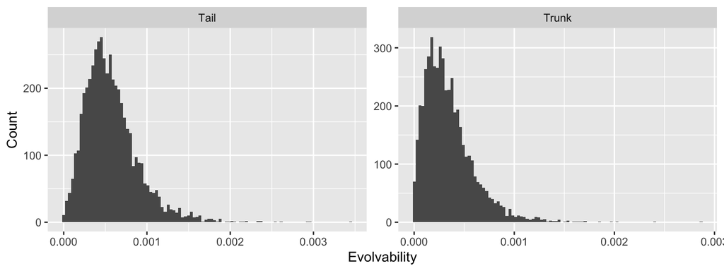

Evolvability as a percentage

|  | Trunk | Tail |
| --- | --- | --- |
| **lower.hdi** | 0.00002188 | 0.001182 |
| **median** | 0.02947 | 0.05171 |
| **mode** | 0.02159 | 0.0482 |
| **upper.hdi** | 0.08241 | 0.117 |
| **pr.lt.hdi** | 0 | 0.001 |
| **pr.gt.hdi** | 0.0498 | 0.0488 |
| **5pc.exceeds** | 0.08234 | 0.1161 |

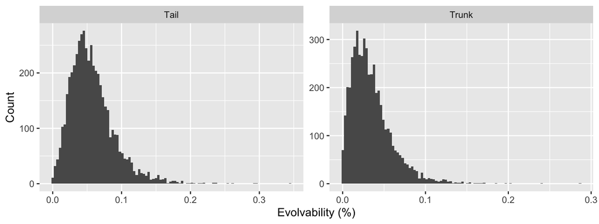

## Tail / Trunk Evolvability

| lower.hdi | median | mode | upper.hdi | pr.lt.hdi | pr.gt.hdi | 5pc.exceeds |
| --- | --- | --- | --- | --- | --- | --- |
| 0.2098 | 1.742 | 1.524 | 17.94 | 1.017 | 1.034 | 12.6 |

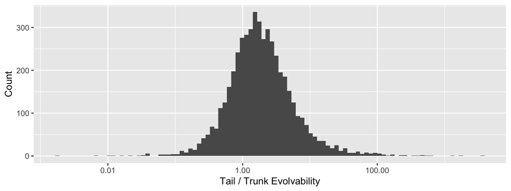

## Evolvability (from G matrix) Approach 1

This is for a random set of selection gradients.  
Multiply eB by 100 to get in units of percent.

| name | lower.hdi | median | mode | upper.hdi | pr.lt.hdi | pr.gt.hdi | 5pc.exceeds |
| --- | --- | --- | --- | --- | --- | --- | --- |
| eB | 0.000032 | 0.000235 | 0.000195 | 0.000503 | 0.0024 | 0.0474 | 0.000497 |
| rB | 0.000033 | 0.000276 | 0.000235 | 0.000612 | 0.0014 | 0.0484 | 0.000607 |
| cB | 0.000016 | 0.000126 | 0.000123 | 0.000268 | 0.0084 | 0.0414 | 0.000259 |
| iB | 0.02915 | 0.4306 | 0.4428 | 0.8046 | 0.0108 | 0.039 | 0.7837 |
| aB | 0.1954 | 0.5694 | 0.5572 | 0.9709 | 0.039 | 0.0108 | 0.9022 |

## Evolvability (from G matrix) Approach 2

This is for a specific set of selection gradients:  
Beta_index = 1 is $\beta = \begin{bmatrix} 0 \\ 1 \end{bmatrix}$ = strong selection for longer tails only  
Beta_index = 2 is $\beta = \begin{bmatrix} -(1/\sqrt2) \\ -(1/\sqrt2) \end{bmatrix}$ = strong selection for shorter trunks and shorter tails  
Beta_index = 3 is $\beta = \begin{bmatrix} (1/\sqrt2) \\ -(1/\sqrt2) \end{bmatrix}$ = strong selection for longer trunks and shorter tails  
Multiply ‘evolvability’ by 100 to get in units of percent.

| Beta_index | metric | lower.hdi | median | mode | upper.hdi | pr.lt.hdi | pr.gt.hdi | 5pc.exceeds |
| --- | --- | --- | --- | --- | --- | --- | --- | --- |
| 1 | evolvability | 0.000012 | 0.000517 | 0.000482 | 0.00117 | 0.001 | 0.0488 | 0.001161 |
| 2 | evolvability | 0.000048 | 0.000442 | 0.000341 | 0.001073 | 0.003 | 0.0468 | 0.001058 |
| 3 | evolvability | 0.000054 | 0.000367 | 0.000307 | 0.00085 | 0.0038 | 0.046 | 0.00084 |
| 1 | respondability | 0.000027 | 0.000535 | 0.000452 | 0.001205 | 0.0014 | 0.0484 | 0.001199 |
| 2 | respondability | 0.000077 | 0.000489 | 0.000403 | 0.001156 | 0.005 | 0.0448 | 0.001117 |
| 3 | respondability | 0.000082 | 0.000416 | 0.000355 | 0.000963 | 0.0072 | 0.0426 | 0.000934 |
| 1 | conditional | 0.000009 | 0.000441 | 0.000381 | 0.001044 | 0.001 | 0.0488 | 0.001036 |
| 2 | conditional | 0 | 0.000335 | 0.000265 | 0.000893 | 0 | 0.0498 | 0.00089 |
| 3 | conditional | 0 | 0.000279 | 0.00024 | 0.0007 | 0 | 0.0498 | 0.0007 |
| 1 | autonomy (cB/eB) | 0.5225 | 0.9276 | 0.9638 | 1 | 0.0498 | 0 | 0.9993 |
| 2 | autonomy (cB/eB) | 0.2049 | 0.8498 | 0.9249 | 1 | 0.0498 | 0 | 0.9988 |
| 3 | autonomy (cB/eB) | 0.2049 | 0.8498 | 0.9249 | 1 | 0.0498 | 0 | 0.9988 |
| 1 | integration | 0 | 0.07236 | 0.03617 | 0.4775 | 0 | 0.0498 | 0.4774 |
| 2 | integration | 0 | 0.1502 | 0.07505 | 0.7951 | 0 | 0.0498 | 0.7949 |
| 3 | integration | 0 | 0.1502 | 0.07505 | 0.7951 | 0 | 0.0498 | 0.7949 |

## Response to selection (%) from covariance. Approach 3

| param | lower.hdi | median | mode | upper.hdi | pr.lt.hdi | pr.gt.hdi | 5pc.exceeds |
| --- | --- | --- | --- | --- | --- | --- | --- |
| Tail : Settle\|Hatch | -0.3895 | 0.04163 | 0.03124 | 0.6064 | 0.02254 | 0.02744 | 0.4804 |
| Trunk : Settle\|Hatch | -0.4929 | -0.01397 | -0.008534 | 0.415 | 0.0296 | 0.02038 | 0.274 |
| Tail : Hatch | -0.3084 | 0.0202 | 0.01612 | 0.428 | 0.02164 | 0.02834 | 0.3303 |
| Trunk : Hatch | -0.08806 | 0.1054 | 0.06452 | 0.6019 | 0.01166 | 0.03832 | 0.5498 |
| NA | -0.4822 | 0.09528 | 0.07946 | 0.8148 | 0.02223 | 0.02776 | 0.6687 |